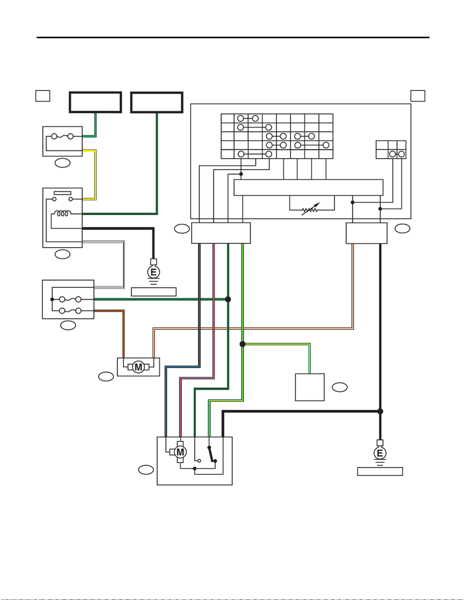

WI-242

Front Wiper and Washer System

WIRING SYSTEM

22.Front Wiper and Washer System

A: WIRING DIAGRAM

1. ENGINE TYPE FA

WI-44441

1a 1a

B280A:

B564

30A

ON

OFF

HI

LO

INT

OFF

MIST

B475

B550

15A

30A

B146

B8

B70A:

B558B:

3

4

B

4

3

2

1

G/B

W/B

W/B1

BR

G/Y

G/B

14

12

GY

G/B

B

B

A2

1

BR/W2

3

5

G/Y1

G/B2

4

R/L

B/L

R/L

B/L

G/Y

G/B

A4

B

BR/W

A1

A3

A2

B3

B2

B

BR

FRONT WIPER

MOTOR

FRONT WASHER

MOTOR

FUSE HOLDER

BODY INTEGRATED UNIT

WIPER RELAY

FRONT

WASHER

SWITCH

FRONT WIPER SWITCH

PC BOARD

COMBINATION SWITCH

FB-42

F/B FUSE NO. 26

(IG)

FUSE HOLDER

REF. TO GND [b]

REF. TO GND [b]

MB-33

MAIN SBF

(B)

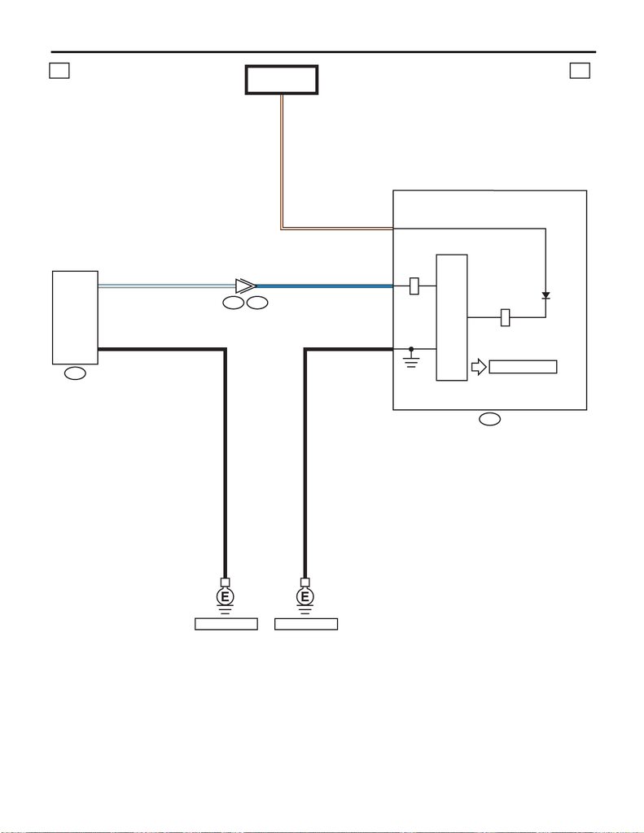

WI-243

Front Wiper and Washer System

WIRING SYSTEM

WI-44442

2

1b 1b

i10

B552 i230

B396

BR/W

20BR/W

21

1

L/B

W/L

B

I/F

I/F

38

2

B

B

B

W/L

L/B

TFT

MICRO COMPUTER

WASHER FLUID LEVEL

SENSOR

COMBINATION METER

FB-12

F/B FUSE NO. 2

(IG)

REF. TO GND [b] REF. TO GND [e]

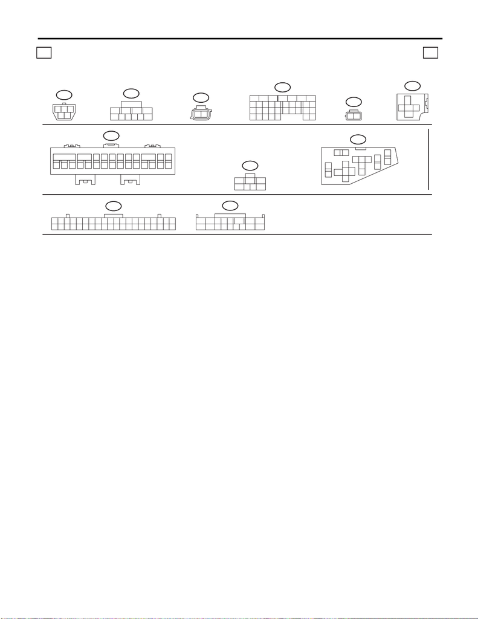

WI-244

Front Wiper and Washer System

WIRING SYSTEM

LIST OF CONNECTORS

1c 1c

12

45

3

3

5

6

1

2

7

4

9

10

8

12

18

2719 20 21 22

23

26

24

25

28 29 3332 3430 31

98

15

1413121110

17

16

1234567

12

2

1

4

3

91

2

232221 262524201918

4

13

12

17

3

16

6

15

587

14

10 11

3

4

56

1

2

7

3

4

12

9

5

7

8

6

10

12

13

11

14

16

17

15

11 12

9

10

7856341

2

15 1613 14 19

18

20

21 22 23 24 26

25

27 28 29 30 31 32 33 34 35 36 37 38 39 40

17

10

13

345 6

14 15 16 17

1211

12 78

9

FUSE HOLDER

RELAY HOLDER

WI-44443

B146

(B)

B475

B:

B558

B8

(GR)

A:

B70

B280

A:

B564

B396

(BR)

i10

(B)

B550

i230

(GR)

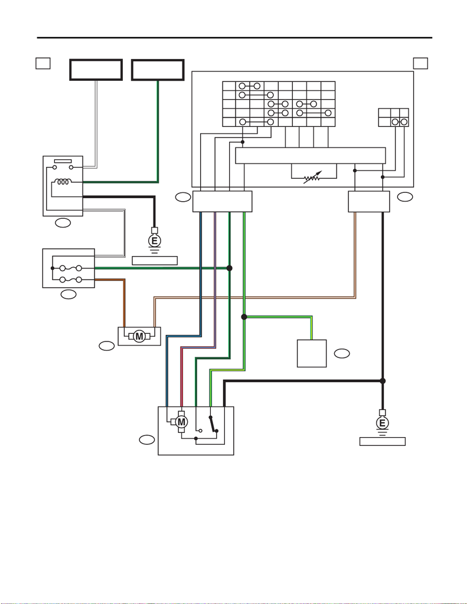

WI-245

Front Wiper and Washer System

WIRING SYSTEM

2. ENGINE TYPE EJ

WI-44444

2a 2a

B280A:

ON

OFF

HI

LO

INT

OFF

MIST

B475

B550

15A

30A

B146

B8

B70A:

B558B:

B

4

3

2

1

G/B

W/B

W/B1

BR

G/B

15

13

W

G/B

B

B

A2

1

BR/W2

3

5

G/Y1

G/B2

4

R/L

B/L

G/Y

R/L

B/L

G/Y

G/B

A4

B

BR/W

A1

A3

A2

B3

B2

B

BR

FRONT WIPER

MOTOR

FRONT WASHER

MOTOR

FUSE HOLDER

BODY INTEGRATED UNIT

WIPER RELAY

FRONT

WASHER

SWITCH

FRONT WIPER SWITCH

PC BOARD

COMBINATION SWITCH

FB-42

F/B FUSE NO. 26

(IG)

REF. TO GND [b]

REF. TO GND [b]

MB-31

SBF-6

(B)

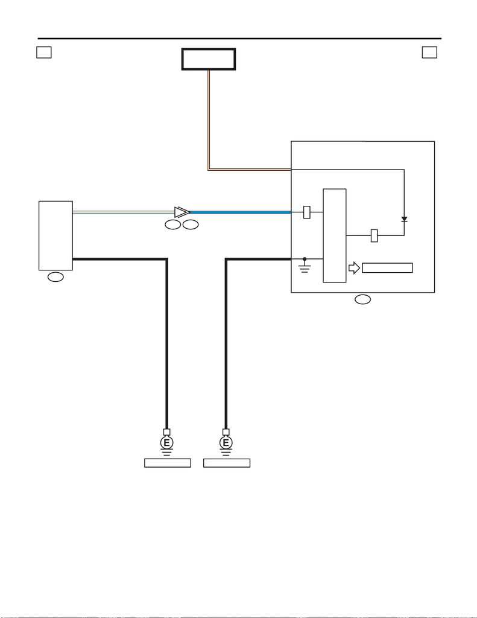

WI-246

Front Wiper and Washer System

WIRING SYSTEM

WI-44445

2

2b 2b

i10

B552 i230

B396

BR/W

20BR/W

21

1

L/B

W/L

B

I/F

I/F

38

2

B

B

B

W/L

L/B

TFT

MICRO COMPUTER

WASHER FLUID LEVEL

SENSOR

COMBINATION METER

FB-12

F/B FUSE NO. 2

(IG)

REF. TO GND [b] REF. TO GND [e]

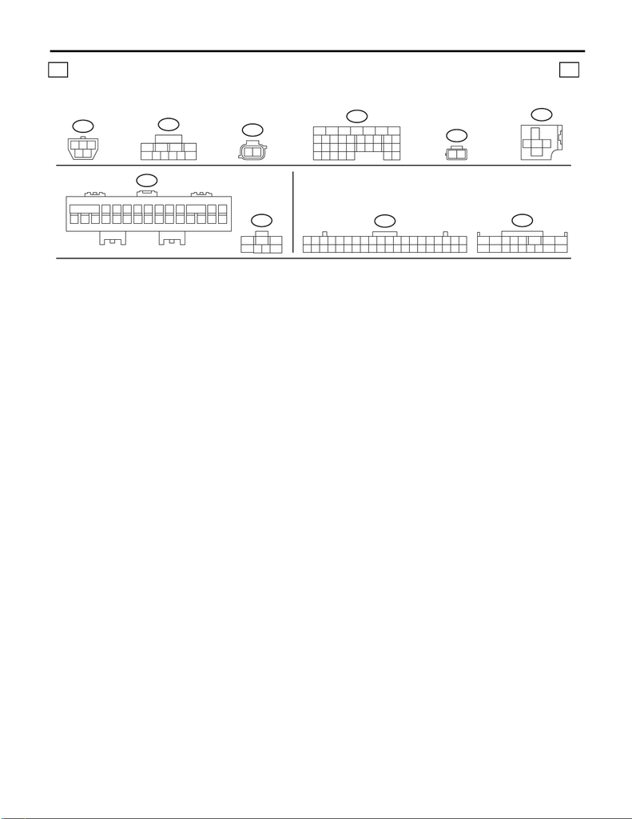

WI-247

Front Wiper and Washer System

WIRING SYSTEM

LIST OF CONNECTORS

2c 2c

12

45

3

3

5

6

1

2

7

4

9

10

8

12

18

2719 20 21 22

23

26

24

25

28 29 3332 3430 31

98

15

1413121110

17

16

1234567

12

2

1

4

3

101

242322 272625212019

5

14

13

18

432

17

7

16

698

15

11 12

3

4

56

1

2

7

11 12

9

10

7856341

2

15 1613 14 19

18

20

21 22 23 24 26

25

27 28 29 30 31 32 33 34 35 36 37 38 39 40

17

10

13

345 6

14 15 16 17

1211

12 78

9

WI-44446

B146

(B)

B475

B:

B558

B8

(GR)

A:

B70

B280

A:

B396

(BR)

i10

(B)

B550

i230

(GR)

FUSE HOLDER